# Ordinary Differential Equations

Yuji Saikai ysaikai@unimelb.edu.au School of Mathematics and Statistics The University of Melbourne

# Introduction

A system of ordinary differential equations (ODEs)
$$\frac{d}{dt}\mathbf{y}(t) =
\mathbf{f}(\mathbf{y}(t))$$

We want to find a function $\mathbf{y}(t)$ that satisfies the system, which is difficult and often impossible.

The corresponding numerical solution is a table that contains $\mathbf{y}$ value for each of different $t$.

We use as a running example the predator–prey model, which is based on the [Lotka-Volterra equations](https://en.wikipedia.org/wiki/Lotka–Volterra_equations).

## Predator–prey model

Used to describe the population dynamics of two species, the one as a predator and the other as a prey.

The model consists of a pair of ODEs:
$$\begin{align}
\frac{dy_1}{dt} &= ay_1 - by_1y_2\\
\frac{dy_2}{dt} &= gby_1y_2 - ey_2
\end{align}$$
where

- $y_1$ : prey population
- $y_2$ : predator population
- $a$ : natural growth rate of prey in the absence of predation
- $b$ : death rate due to the predation
- $g$ : birth rate of predator due to the captured prey
- $e$ : natural death rate of predator.

The system is known to have periodic solutions, which do not allow simple expressions.

Easy to obtain an implicit equation of $y_1$ and $y_2$.
$$\begin{alignat}{2}
&&(ay_1-by_1y_2)dy_2 &= (gby_1y_2-ey_2)dy_1\\
&\Leftrightarrow\quad &\int \frac{a-by_2}{y_2}dy_2 &= \int
\frac{gby_1-e}{y_1}dy_1\\
&\Leftrightarrow\quad & c &=
gby_1-e\log(y_1)+by_2-a\log(y_2)
\end{alignat}$$
where $c$ is a constant.

With $a=0.05$, $b=0.0002$, $g=0.8$, $e=0.03$, and $c=-0.3$, we have the following orbit in a phase space.

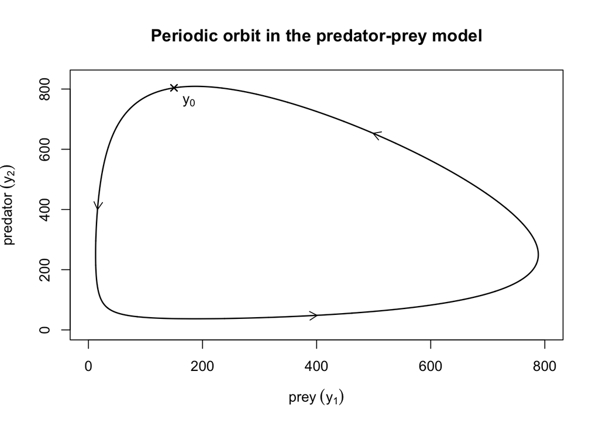

```r
a <- 0.05
b <- 0.0002
g <- 0.8
e <- 0.03
c <- -0.3
y1 <- seq(0, 800, length=1000)
y2 <- seq(0, 830, length=1000)
out <- outer(y1, y2, function(y1,y2) g*b*y1 - e*log(y1) + b*y2 - a*log(y2) )
contour(y1, y2, out, levels=c, lwd=1.5, drawlabels=F,
        xlab=bquote("prey" ~ (y[1])), ylab=bquote("predator" ~ (y[2])))
from_x <- c(16.05, 400, 500)
from_y <- c(401, 48, 652.3)
to_x <- c(16, 401, 499)
to_y <- c(400, 48.1, 653)
y0 <- c(150, 804)
points(y0[1], y0[2], pch=4, lwd=1.5)
text(y0[1], y0[2]-50, expression(y[0]), pos=4)
arrows(from_x, from_y, to_x, to_y, length=.1)
title("Periodic orbit in the predator-prey model")
```

## Numerical solutions

If we knew $\mathbf{y}(t)$ on the right-hand side of the above ODEs, a solution would be a usual integral with respect to $t$:
$$\mathbf{y}(t) = \int \mathbf{f}(\mathbf{y}(t))dt
.$$
An initial value problem
$$\mathbf{y}(t_1) = \mathbf{y}(t_0) + \int_{t_0}^{t_1}
\mathbf{f}(\mathbf{y}(t))dt ,$$

*Solving a differential equation is doing integration*.

Remember whether it is analytical or numerical integration, *when it is hard, we approximate the integrand by simple functions*.

Why don’t we apply the same idea here — approximating an unknown function $\mathbf{y}(t)$?

Starting with given $\mathbf{y}(t_0)$ for $t=t_0$, we can sequentially compute/simulate $\mathbf{y}(t_1), \mathbf{y}(t_2), \dots$ and build a solution table as follows.

| $t$ | $\mathbf{y}(t)$ |
| --- | --- |
| $t_0$ | $\mathbf{y}(t_0)$ |
| $t_1$ | $\mathbf{y}(t_0) + \int_{t_0}^{t_1} \mathbf{f}(\mathbf{y}(t))dt$ |
| $t_2$ | $\mathbf{y}(t_1) + \int_{t_1}^{t_2} \mathbf{f}(\mathbf{y}(t))dt$ |
| $\vdots$ |  |

# Euler’s method

Let’s try linear approximation because its derivative is a constant and easy to integrate.

Let $\hat{\mathbf{y}}(t)$ be an approximation to $\mathbf{y}(t)$ for $t>0$, and $\hat{\mathbf{y}}(0) = \mathbf{y}(0)$.

If $\hat{\mathbf{y}}(t)$ is linear, then
$$\mathbf{f}(\hat{\mathbf{y}}(t)) = \frac{d}{dt}\hat{\mathbf{y}}(t)$$
is a constant. A natural choice is
$$\mathbf{f}(\hat{\mathbf{y}}(t)) = \mathbf{f}(\hat{\mathbf{y}}(0))$$
for all $t\in[0,h]$, and we can easily compute $\mathbf{f}(\hat{\mathbf{y}}(0))$ using the knowledge of $\mathbf{f}$ and $\hat{\mathbf{y}}(0) = \mathbf{y}(0)$.

Thus,
$$\begin{align}
\hat{\mathbf{y}}(h) &= \hat{\mathbf{y}}(0) + \int_0^h
\mathbf{f}(\hat{\mathbf{y}}(0))dt\\
&= \hat{\mathbf{y}}(0) +
h\mathbf{f}(\hat{\mathbf{y}}(0))
\end{align}$$

Euler’s method for numerically solving ODEs is to make the following repeated approximation until $t=nh+h$:
$$\begin{align}
\hat{\mathbf{y}}(nh+h) &= \hat{\mathbf{y}}(nh) + \int_{nh}^{nh+h}
\mathbf{f}(\hat{\mathbf{y}}(nh))dt\\
&= \hat{\mathbf{y}}(nh) +
h\mathbf{f}(\hat{\mathbf{y}}(nh))
\end{align}$$
for $n\in\{0,1,\dots\}$.

Let’s illustrate it using the predator–prey model. Each process starts at $\mathbf{y}_0=(150, 804)$, which is a point on the orbit.

```r
LV <- function(y) c(a*y[1] - b*y[1]*y[2], g*b*y[1]*y[2] - e*y[2])
```

```r
euler <- function(f, y0, h, N) {
  # Solution y(t) stored in a matrix for t∈{0,h,2h,...Nh}
  Y <- matrix(nrow=N+1, ncol=length(y0))

  Y[1,] <- y0
  for (n in 1:N) {
    Y[n+1,] <- Y[n,] + h*f(Y[n,])
  }
  return(Y)
}
```

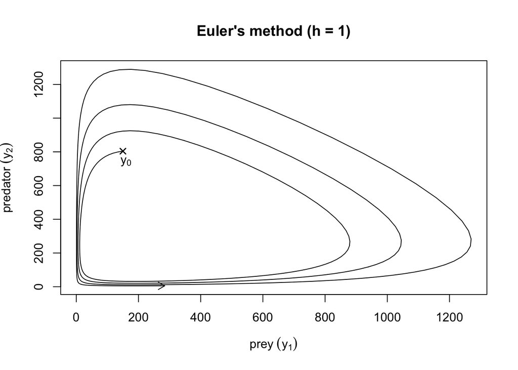

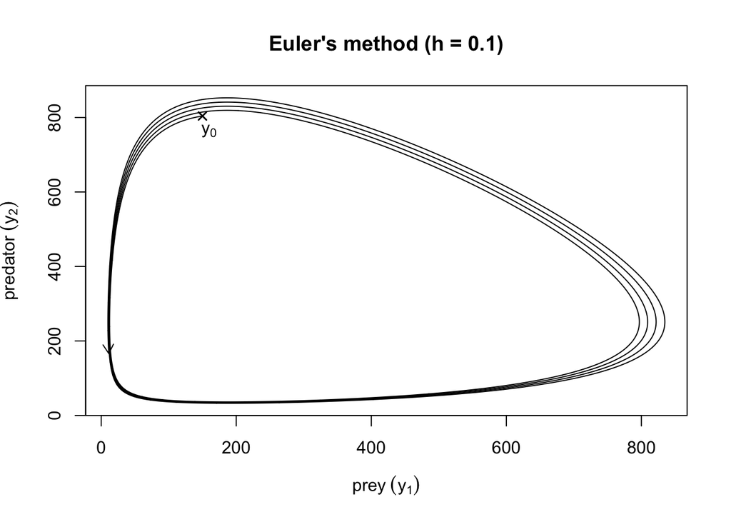

```r
for (h in c(1, 0.1)) {
  N <- 880/h
  Y <- euler(LV, y0, h, N)
  plot(Y[,1], Y[,2], type="l", xlab=bquote("prey" ~ (y[1])), ylab=bquote("predator" ~ (y[2])))
  points(Y[1,1], Y[1,2], pch=4, lwd=1.5)
  text(Y[1,1]+10, Y[1,2], expression(y[0]), pos=1)
  arrows(Y[N+1,1], Y[N+1,2],
         Y[N+1,1]+LV(Y[N+1,])[1], Y[N+1,2]+LV(Y[N+1,])[2], length=.1)
  title(paste("Euler's method (h = ", h, ")", sep=""))
}
```

With smaller $h$ produces smaller errors.

The errors are smaller at the bottom-left and larger at the top-right. Why?

We should not excessively rely on small $h$.

Our task is to come up with better approximation of $\mathbf{y}(t)$ to reduce errors without decreasing $h$.

Remember that, when approximating $\mathbf{y}(t)$, we make two decisions: *linearity* and its *slope*.

Keep the linearity because it allows us to eliminate the dependency of the integrand $\mathbf{f}(\hat{\mathbf{y}}(t))$ on $t\in[nh,nh+h]$.

So, we try to engineer better slopes than the naïve choice $\mathbf{f}(\hat{\mathbf{y}}(nh))$.

(to be continued next week…)